# Reproducible Research: Peer Assessment 1

Diogo_Provete

## Loading and preprocessing the data

library(lattice)

1. Load the data

```r
act_data<-read.csv(unz("activity.zip", "activity.csv"))
head(act_data)
```

```
##   steps       date interval
## 1    NA 2012-10-01        0
## 2    NA 2012-10-01        5
## 3    NA 2012-10-01       10
## 4    NA 2012-10-01       15
## 5    NA 2012-10-01       20
## 6    NA 2012-10-01       25
```

```r
summary(act_data)
```

```
##      steps                date          interval
##  Min.   :  0.00   2012-10-01:  288   Min.   :   0.0
##  1st Qu.:  0.00   2012-10-02:  288   1st Qu.: 588.8
##  Median :  0.00   2012-10-03:  288   Median :1177.5
##  Mean   : 37.38   2012-10-04:  288   Mean   :1177.5
##  3rd Qu.: 12.00   2012-10-05:  288   3rd Qu.:1766.2
##  Max.   :806.00   2012-10-06:  288   Max.   :2355.0
##  NA's   :2304     (Other)   :15840
```

2. Process/transform the data (if necessary) into a format suitable for your analysis

## What is mean total number of steps taken per day?

1.Calculate the total number of steps taken per day

```r
Sum_steps<-aggregate(act_data$steps, by=list(act_data$date), FUN=sum, na.rm= TRUE)
names(Sum_steps) <- c("date", "total")
Sum_steps
```

```
##          date total
## 1  2012-10-01     0
## 2  2012-10-02   126
## 3  2012-10-03 11352
## 4  2012-10-04 12116
## 5  2012-10-05 13294
## 6  2012-10-06 15420
## 7  2012-10-07 11015
## 8  2012-10-08     0
## 9  2012-10-09 12811
## 10 2012-10-10  9900
## 11 2012-10-11 10304
## 12 2012-10-12 17382
## 13 2012-10-13 12426
## 14 2012-10-14 15098
```

[output cut: 47 more lines]

2. Make a histogram of the total number of steps taken each day

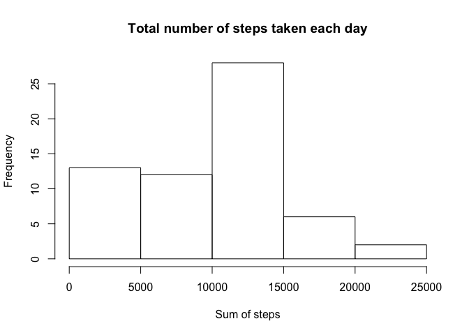

```r
hist(Sum_steps$total, breaks = "FD", main = paste("Total number of steps taken each day"), xlab = "Sum of steps")
```

```r
step.mean <- mean(Sum_steps$total, na.rm = TRUE)
step.median <- median(Sum_steps$total, na.rm = TRUE)
```

## What is the average daily activity pattern?

1. Make a time series plot (i.e. type = “l”) of the 5-minute interval (x-axis) and the average number of steps taken, averaged across all days (y-axis)

```r
mean_act <- aggregate(act_data$steps,
                       by=list(act_data$interval),
                       FUN=mean,
                       na.rm=TRUE)
names(mean_act) <- c("interval", "mean")
head(mean_act)
```

```
##   interval      mean
## 1        0 1.7169811
## 2        5 0.3396226
## 3       10 0.1320755
## 4       15 0.1509434
## 5       20 0.0754717
## 6       25 2.0943396
```

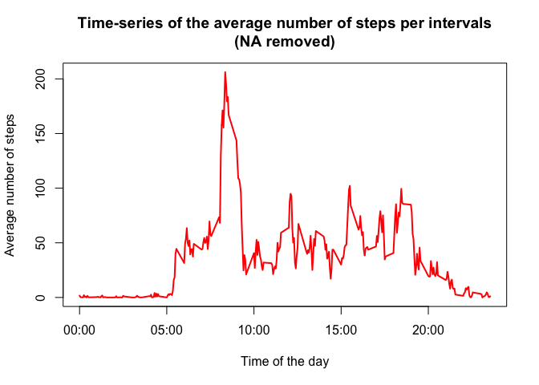

```r
labels <- c("00:00", "05:00", "10:00", "15:00", "20:00")
labels.at <- seq(0, 2000, 500)
act_data$interval <- as.factor(as.character(act_data$interval))
intervals <- data.frame(intervals = as.numeric(levels(act_data$interval)), mean_act)
intervals <- intervals[order(intervals$intervals), ]
plot(mean_act$interval,
     mean_act$mean,
     type="l",
     col="red",
     lwd=2,
     xlab="Time of the day",
     ylab="Average number of steps",
     main="Time-series of the average number of steps per intervals\n(NA removed)",
     xaxt = "n")
axis(side = 1, at = labels.at, labels = labels)
```

2. Which 5-minute interval, on average across all the days in the dataset, contains the maximum number of steps?

```r
max_pos <- which(mean_act$mean == max(mean_act$mean))
max_interval <- mean_act[max_pos, 1]
```

The 5-minute interval that contains the maximum of steps, on average across all days, corresponds to the interval between 8:35 AM and 8:40 AM.

## Imputing missing values

1. Calculate and report the total number of missing values in the dataset (i.e. the total number of rows with NAs)

```r
activity_data <- complete.cases(act_data)
data_missing <- length(activity_data[activity_data==FALSE])
```

The total number of missing values is 2304

2. Devise a strategy for filling in all of the missing values in the dataset. The strategy does not need to be sophisticated. For example, you could use the mean/median for that day, or the mean for that 5-minute interval, etc.

```r
# Find the NA positions
na_pos <- which(is.na(act_data$steps))

# Create a vector of means
mean_vec <- rep(mean(act_data$steps, na.rm=TRUE), times=length(na_pos))
```

3. Create a new dataset that is equal to the original dataset but with the missing data filled in.

```r
act_data[na_pos, "steps"] <- mean_vec
head(act_data)
```

```
##     steps       date interval
## 1 37.3826 2012-10-01        0
## 2 37.3826 2012-10-01        5
## 3 37.3826 2012-10-01       10
## 4 37.3826 2012-10-01       15
## 5 37.3826 2012-10-01       20
## 6 37.3826 2012-10-01       25
```

[figure not shown]

```r
# Compute the histogram of the total number of steps each day
hist(Sum_steps$total,
     breaks=seq(from=0, to=25000, by=2500),
     col="red",
     xlab="Total number of steps",
     ylim=c(0, 30),
     main="Histogram of the total number of steps taken each day\n(NA replaced by mean value)")
```

## Are there differences in activity patterns between weekdays and weekends?

1. Create a new factor variable in the dataset with two levels – “weekday” and “weekend” indicating whether a given date is a weekday or weekend day.

```r
act_data$date <- as.POSIXct(act_data$date, format="%Y-%m-%d")

# Compute the weekdays from the date attribute
act_data <- data.frame(date=act_data$date,
                           weekday=tolower(weekdays(act_data$date)),
                           steps=act_data$steps,
                           interval=act_data$interval)

# Compute the day type (weekend or weekday)
act_data <- cbind(act_data,
                      daytype=ifelse(act_data$weekday == "saturday" |
                                     act_data$weekday == "sunday", "weekend",
                                     "weekday"))

# Create the final data.frame
activity <- data.frame(date=act_data$date,
                       weekday=act_data$weekday,
                       daytype=act_data$daytype,
                       interval=act_data$interval,
                       steps=act_data$steps)
```

2. Make a panel plot containing a time series plot (i.e. type = “l”) of the 5-minute interval (x-axis) and the average number of steps taken, averaged across all weekday days or weekend days (y-axis). See the README file in the GitHub repository to see an example of what this plot should look like using simulated data.

```r
library(lattice)

# Compute the average number of steps taken, averaged across all daytype variable
mean_data <- aggregate(act_data$steps,
                       by=list(act_data$daytype,
                               act_data$weekday, act_data$interval), mean)

# Rename the attributes
names(mean_data) <- c("daytype", "weekday", "interval", "mean")
head(mean_data)
```

```
##   daytype  weekday interval     mean
## 1 weekday   friday        0 8.307244
## 2 weekday   monday        0 9.418355
## 3 weekend saturday        0 4.672825
## 4 weekend   sunday        0 4.672825
## 5 weekday thursday        0 9.375844
## 6 weekday  tuesday        0 0.000000
```

[figure not shown]

```r
xyplot(mean ~ interval | daytype, mean_data,
       type="l",
       lwd=1,
       xlab="Interval",
       ylab="Number of steps",
       layout=c(1,2))
```